# HW6 on cereals

nicole higgins

2023-03-07

### SVD and breakfast cereals

The SVD can be used to take a two-dimensional or three-dimensional snapshot of high-dimensional data, so that dimensionally-challenged human beings can see it. In this assignment, you will use the top two singular values to project some data down to 2-dimensional space where you can interpret it.

Here is a data set on cereals:

```r
cereal = read.csv("cereal.csv")
A =  as.matrix(cereal[,4:16])
Names = as.matrix(cereal[,1])
```

The matrix $A$ has nutritional information (in 13 categories) about 77 breakfast cereals (one per row of $A$). The names of the cereals are stored as the vector “Names”. This dataset is from Kaggle.

The columns are measured in differing units, so we’ll do some preprocessing before we take the SVD.

## Q1 Preprocessing and SVD

Within each column of $A$, subtract off the mean. Then, within each column of $A$, divide by the square root of the variance, like “c <- c / sqrt(var(c))” if c were a column of $A$. Plot the singular values of the modified matrix $A$. Comment on the plot.

```r
for (i in 1:13){
  colMean <- sum(A[,i])/77
  colSqVar <- sqrt(var(A[,i]))
  for (j in 1:77){
    A[j,i] <- (A[j,i] - colMean)/colSqVar
  }
}
```

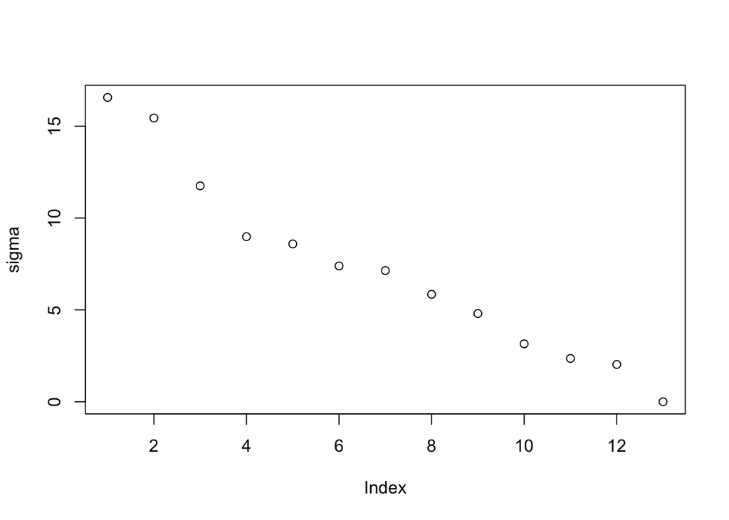

```r
out <- svd(A)
sigma <- out$d

plot(sigma)
```

**the first two, maybe three, sv’s are larger than the remaining ten. this means that they alone represent a good chunk of the data.**

## Q2 2D plot for high-dimensional cereal vectors

Use the vectors $x = U_1$ and $y = U_2$ from the SVD as the $x$ and $y$ coordinates of points in the plane. Plot these points. Label the $i^{th}$ point with the $i^{th}$ brand of cereal. To do this, you can use the following command after your plotting command:

```
text(x,y,Names,cex=0.3) # the cex= makes the text smaller
```

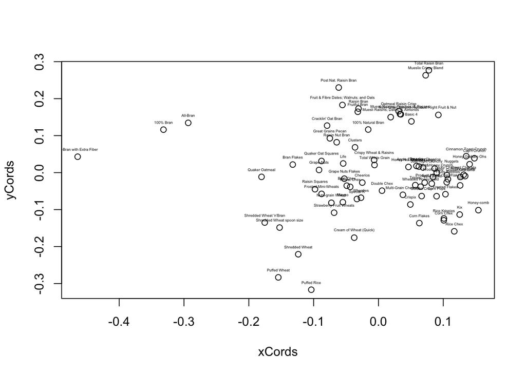

```r
# setting values
xCords <- out$u[,1]
yCords <- out$u[,2]

plot(xCords, yCords) # plotting coordinates
text(xCords, yCords+.02, Names, cex=0.3) # the cex= makes the text smaller
```

## Q3 Outliers

Do any of the cereals look like outliers to you?

**yes, ‘Bran with Extra Fiber’ is the most obvious outlier, followed by ‘100% Bran’ and ‘All-Bran’. some of the lowermost points appear to be outliers too, including ‘Puffed Rice’, ‘Puffed Wheat’, and ‘Shredded Wheat’**

## Q4 Similar names

The two cereals “All-Bran” and “100% Bran” have very similar names. Do they appear close together on the plot?

**yes they do, near (-0.3, 0.1)**

## Q5 Gift for friend

Suppose that I have never eaten any of these cereals but I have a friend who really likes “Great Grains Pecan.” I want to bring some to them as a surprise gift. Unfortunately, the store has run out of this cereal and I have to choose something similar instead. As a second choice, which cereal might make a good gift for my friend?

**the cereal closest to ‘Great Grains Pecan’ on the graph is ‘Raisin Nut Bran’, so that would be a good second choice**

## Q6 Interpreting $U_1$

Which cereals have the most extreme positions in the $U_1$-direction? If you look at those rows in the original matrix, do you notice anything special about their values? Can you find an interpretation of the right/left direction in your plot?

**the U_1 direction seems to well-describe a cereal’s fiber content, with the left being the most fiber, and the right being the least. while this axis isn’t exactly equal to the fiber values, it gives a good sense of it in terms of order and rank.**